# Linear Search

Linear Search didefinisikan sebagai algoritma pencarian di mana daftar atau kumpulan data dijelajahi dari satu ujung untuk menemukan nilai yang diinginkan.

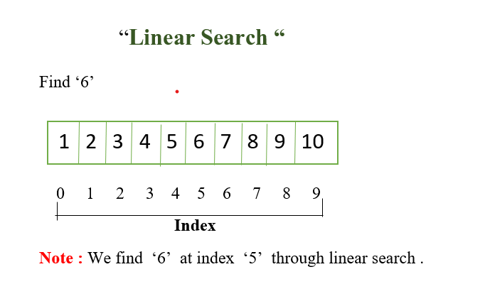

Linear Search bekerja dengan memeriksa setiap elemen dalam daftar secara berurutan hingga nilai yang diinginkan ditemukan atau akhir daftar tercapai.

## Sifat-sifat Linear Search:

- Kompleksitas Waktu: Kompleksitas waktu kasus terburuk dari linear search adalah o(n), di mana n adalah ukuran array.
- Kompleksitas Ruang : Linear Search membutuhkan jumlah memori konstan untuk dijalankan.
- Efisiensi: Linear Search efisien untuk kumpulan data kecil tetapi menjadi tidak efisien untuk kumpulan data yang lebih besar. Dalam praktiknya, linear search sering digunakan sebagai subrutin dalam algoritma yang lebih kompleks.
- Implementasi: Linear Search dapat dengan mudah diimplementasikan menggunakan perulangan, dengan setiap iterasi membandingkan nilai target dengan elemen array saat ini.

## Penerapan Linear Search:

Linear Searxh memiliki beberapa aplikasi praktis dalam ilmu komputer dan bidang lainnya. Berikut beberapa contohnya:

- Pencarian Buku Telepon : Linear Searxh dapat digunakan untuk menelusuri buku telepon guna menemukan nama seseorang berdasarkan nomor teleponnya.
- Pemeriksa Ejaan : Algoritma membandingkan setiap kata dalam dokumen deengan kamus kata-kata yang dieja dengan benar hingga ditemukan kecocokan.
- Mencari Nilai Minimum dan Maksimum: Linear Search dapat digunakan untuk menemukan nilai minimum dan maksimum dalam sebuah array atau daftar.
- Mencari melalui data yang tidak terurut: Linear Search berguna untuk mencari melalui data yang tidak terurut.

## Keunggulan Linear Search:

Berikut beberapa keunggulan menggunakan Linear Search:

- Kesederhanaan: Linear Search adalah algoritma yang sangat sederhana untuk dipahami dan diimplementasikan.
- Berfungsi dengan data yang tidak terurut : Linear Search bekerja dengan baik dengan data yang tidak terurut. Pencarian ini tidak memerlukan pra-pemrosesan atau pengurutan data sebelum melakukan pencarian.
- Penggunaan memori rendah: Linear Search hanya membutuhkan sedikit memori untuk menyimpan indeks elemen yang sedang dicari.
- Mudah di-debug: Karena Linear Search adalah algoritma yang sederhana, maka mudah untuk melakukan debugging dan mengatasi masalah apa pun yang mungkin muncul.

## Linear Search Algorithm

Diberikan sebuah array, arr[] yang berisi n bilangan bulat, dan sebuah elemen bilangan bulat x , tentukan apakah elemen x ada dalam array tersebut. Kembalikan indeks kemunculan pertama x dalam array, atau -1 jika tidak ada.

```
Input : arr[] = [1, 2, 3, 4], x = 3
Output : 2
Penjelasan : Terdapat satu kasus uji dengan array [1, 2, 3, 4] dan elemen yang dicari adalah 3. Karena 3 terdapat pada indeks 2, maka outputnya adalah 2.

Input : arr[] = [10, 8, 30, 4, 5], x = 5
Output : 4
Penjelasan : Untuk array [10, 8, 30, 4, 5], elemen yang dicari adalah 5 dan berada di indeks 4. Jadi, outputnya adalah 4.

Input : arr[] = [10, 8, 30], x = 6
Output : -1
Penjelasan : Elemen yang dicari adalah 6 dan tidak ada, jadi kita mengembalikan -1.
```

Dalam Linear Search, kita mengulangi semua elemen dalam array dan memeriksa apakah elemen saat ini sama dengan elemen target. Jika kita menemukan elemen yang sama dengan elemen target, maka kembalikan indeks elemen saat ini. Jika tidak, jika tidak ada elemen yang sama dengan elemen target, maka kembalikan -1 karena elemen tersebut tidak ditemukan. Linear Search juga dikenal sebagai pencarian sekuensial .

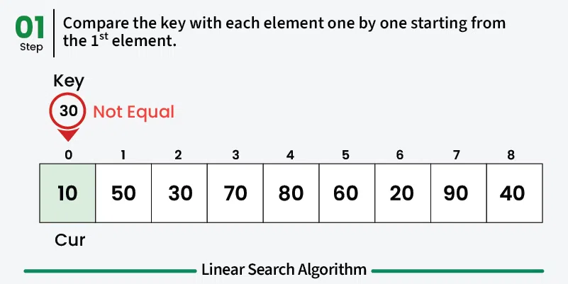

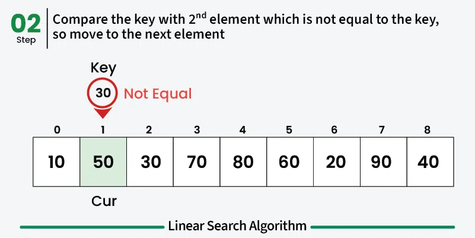

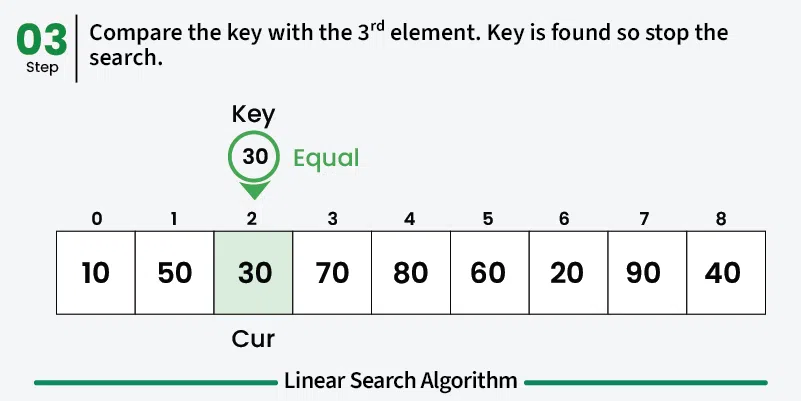

```python
def search(arr, x):
    n = len(arr)

    # Iterate over the array in order to
    # find the key x
    for i in range(0, n):
        if (arr[i] == x):
            return i
    return -1

if __name__ == "__main__":
    arr = [2, 3, 4, 10, 40]
    x = 10

    result = search(arr, x)
    if(result == -1):
        print("Element is not present in array")
    else:
        print("Element is present at index", result)
```

```
Element is present at index 3
```

## Kompleksitas Waktu dan Ruang dari Algoritma Linear Search:

### Kompleksitas Waktu:

- Kasus Terbaik: Dalam kasus terbaik, kunci mungkin ada di indeks pertama. Jadi kompleksitas kasus terbaik adalah O(1)
- Kasus Terburuk: Dalam kasus terburuk, kunci mungkin berada di indeks terakhir, yaitu berlawanan dengan akhir dari mana pencarian dimulai dalam daftar. Jadi kompleksitas kasus terburuknya adalah O(N) di mana N adalah ukuran daftar.
- Kasus Rata-Rata: O(N)

**Ruang Tambahan**: O(1) karena selain variabel untuk melakukan iterasi melalui daftar, tidak ada variabel lain yang digunakan.

## Penerapan Algoritma Linear Search:

- **Daftar yang Tidak Terurut**: Ketika kita memiliki array atau daftar yang tidak terurut, Linear Search paling sering digunakan untuk menemukan elemen apa pun dalam koleksi tersebut.
- **Kumpulan Data Kecil**: Linear Search lebih disukai daripada pencarian biner ketika kita memiliki kumpulan data kecil.
- **Pencarian pada Linked List**: Dalam implementasi linked list, pencarian linear umumnya digunakan untuk menemukan elemen di dalam list. Setiap node diperiksa secara berurutan hingga elemen yang diinginkan ditemukan.
- **Implementasi Sederhana**: Linear Search jauh lebih mudah dipahami dan diimplementasikan dibandingkan dengan Binary Search atau Pencarian Ternary.